# Chi-Square and T tests on Iris Data

### About the Experiment

For this experiment I will be using the `iris` data set. Below is a quick look at the data set for the uninitiated.

```r
data(iris)
iris <- iris[iris$Species != "virginica",]
iris$Species<- factor(iris$Species)
head(iris)
```

```
##   Sepal.Length Sepal.Width Petal.Length Petal.Width Species
## 1          5.1         3.5          1.4         0.2  setosa
## 2          4.9         3.0          1.4         0.2  setosa
## 3          4.7         3.2          1.3         0.2  setosa
## 4          4.6         3.1          1.5         0.2  setosa
## 5          5.0         3.6          1.4         0.2  setosa
## 6          5.4         3.9          1.7         0.4  setosa
```

Typically, `iris` data set in R is used to predict the `Species` based on all other features.

However, before building a prediction model it is always a good practice to explore the relationship between depedant and indendant variables. Below is what you can expect from this post.

1. Convert the `Petal.Width` columns to a categorical variable
2. Drop `Petal.Width` column
3. Perform Chi-Sqare test and interpret results
4. Perform t test and interpret results
5. Conclusion

So let’s get started.

### 1. Convert the `Petal.Width` columns to a categorical variable

There are multiple ways to convert a continuous variable to a categorical variable. Before we do that let’s look at some descriptive statistics of this variable.

1. There are a total of 100 observation
2. The range of these observations is 0.1 to 1.8
3. Below is the summary

```r
summary(iris$Petal.Width)
```

```
##    Min. 1st Qu.  Median    Mean 3rd Qu.    Max.
##   0.100   0.200   0.800   0.786   1.300   1.800
```

We will break the variable into 2 categories, `Below` and `Above` the median value.

```r
iris$Petal.Width.Cat <- cut(iris$Petal.Width, breaks = quantile(iris$Petal.Width, probs = seq(0, 1, 0.5)), include.lowest = TRUE)
levels(iris$Petal.Width.Cat) <- c("Below", "Above")
head(iris)
```

```
##   Sepal.Length Sepal.Width Petal.Length Petal.Width Species
## 1          5.1         3.5          1.4         0.2  setosa
## 2          4.9         3.0          1.4         0.2  setosa
## 3          4.7         3.2          1.3         0.2  setosa
## 4          4.6         3.1          1.5         0.2  setosa
## 5          5.0         3.6          1.4         0.2  setosa
## 6          5.4         3.9          1.7         0.4  setosa
##   Petal.Width.Cat
## 1           Below
## 2           Below
## 3           Below
## 4           Below
## 5           Below
## 6           Below
```

### 2. Drop `Petal.Width` column

Now we will drop the `Petal.Width Column` with the below code.

```r
iris <- iris[,!(names(iris) %in% "Petal.Width")]
head(iris)
```

```
##   Sepal.Length Sepal.Width Petal.Length Species Petal.Width.Cat
## 1          5.1         3.5          1.4  setosa           Below
## 2          4.9         3.0          1.4  setosa           Below
## 3          4.7         3.2          1.3  setosa           Below
## 4          4.6         3.1          1.5  setosa           Below
## 5          5.0         3.6          1.4  setosa           Below
## 6          5.4         3.9          1.7  setosa           Below
```

### 3. Perform few tests and inferential statistics

A. `Species` Vs `Petal.Width.Cat`

Lets look if there is any interaction between `Species` and `Petal.Width.Cat`. Since these two are categorical variables we will use a *chi-square* test. The starting point is to take a look at the contingency table.

```r
cont <- table(iris$Petal.Width.Cat, iris$Species)
cont
```

```
##
##         setosa versicolor
##   Below     50          0
##   Above      0         50
```

To perform the `chi-square` test we will assume the null hypothesis as below:

**H0** : The `Petal.Width.Cat` has no affect on the `Species`

Consequently, the alternate hypotheses will be defined as below:

**Ha** : The `Petal.Width.Cat` has **some** affect on the `Species`

We will perform the test using `chisq.test` function in R.

```r
Xsqt <- chisq.test(cont)
Xsqt
```

```
##
##  Pearson's Chi-squared test with Yates' continuity correction
##
## data:  cont
## X-squared = 96.04, df = 1, p-value < 2.2e-16
```

As we can see from the results above, the `p-value` is 1.125856510^{-22} which is quite smaller then the threshold value of `5%`. This enables us to safely reject the null hypothesis and accept the alternalte hypothesis. In other words, `Petal.Width.Cat` has an impact on `Species` which allows us to conclude that `Petal.Width.Cat` is a good predictor for `Species`.

B. `Species` Vs `Sepal.Length`

Now, we will explore the replatioship between `Species` and `Sepal.Length`. One is a categorical variable and the other is a continuous variable. To get a quick insight in to if one affects the other we can look at the box plot.

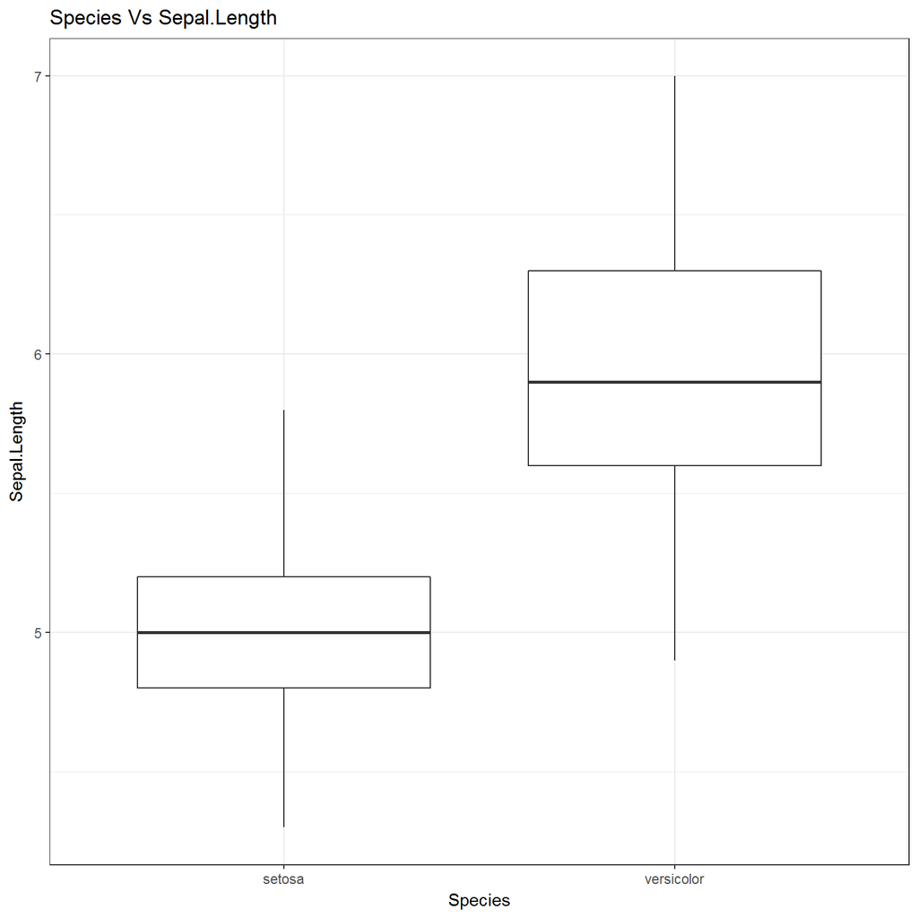

```r
library(ggplot2)
ggplot(iris, aes(x = Species, y = Sepal.Length)) + geom_boxplot() + labs(title = "Species Vs Sepal.Length", x = "Species", y = "Sepal.Length") + theme_bw()
```

For the test below are the hypotheses:

Null Hypothesis **H0** : `Sepal.Length` has no affect on `Species`. That is to say that the difference between the observed `Sepal.Length` values for various `Species` are not statistically different

Alternate Hypothese **Ha** : `Sepal.Length` has some affect on `Species`. That is to say that the difference between the observed `Sepal.Length` values for various `Species` are infact different from each other

```r
x <- iris[iris$Species == "setosa", ]$Sepal.Length
y <- iris[iris$Species == "versicolor", ]$Sepal.Length
tt <- t.test(x, y, paired = FALSE, alternative = "two.sided", var.equal = FALSE)
tt
```

```
##
##  Welch Two Sample t-test
##
## data:  x and y
## t = -10.521, df = 86.538, p-value < 2.2e-16
## alternative hypothesis: true difference in means is not equal to 0
## 95 percent confidence interval:
##  -1.1057074 -0.7542926
## sample estimates:
## mean of x mean of y
##     5.006     5.936
```

As we can observe from from the results above the `p=value` which is 3.746742610^{-17} is significantly lower than our threshold of 5%. Hence, we can reject the null hypothesis and accept the alternative.

### Conclusion

In this articale we have seen how to practically perform a `chi-sqaure test` and a `t test` when exploring the data. Especially, these tools become quite handly to understand the relationship between dependant and independant variables before building machine learning models. Depending on results of various tests we can choose which models to include or exclude from our prediction models to enhance the performance of the models.

December 21, 2016